# TSoilWaterModelR

Author

Agronomy and Crop Science Group, Kiel University

Published

October 20, 2026

# 1 Introduction

Model component for adding root soil water uptake to the simulation of vertical (1D) soil water transport The distribution of water uptake over the soil layers and the calculation of drought limited water uptake can be calculated with different options

## 1.1 Ancestor classes

The class TSoilWaterModelR has the following ancestor classes shown in Table Table 1.

Table 1: Ancestor classes of TSoilWaterModelR.

| AncestorClass | Namespace |
| --- | --- |
| TSoilWaterMod | USoilWaterMod |
| TLayeredSoil | UlayeredSoil |
| TPlantRelatedSubMod | UAbstractPlant |
| TSubmodel | UMod |
| TGraphicControl | Vcl.Controls |
| TControl | Vcl.Controls |
| TComponent | System.Classes |
| TPersistent | System.Classes |
| TObject | System |

TRUE

# 2 Scientific Background

The TSoilWaterModelR module simulates add root water uptake to its ancestor component TSoilWaterMod, which simulates the vertical transport of water in the soil profile.

Root water uptake is induced by the process of canopy transpiration in order to compensate plant water loss. But there exist physical limitations of the rate of total water uptake which can be seen by the sum of the maximum transport rates to the segments of the whole root system. These transport rates are governed by the maximum soil water potential difference between the root surface, the unsaturated hydraulic conductivity in the vicinity of the roots and the water uptake rate per unit of root length which can be approximated in a first step by the ratio of transpiration rate to total root length. However, root water uptake and transpiration are usually regulated down before this situation is reached due to stomata opening control in which physical signals like the leaf water potential, environmental signals like the saturation vapor deficit and the irradiation but also hormonal signalling mechanisms by absissic acid (ABA) are involved.

The component TSoilWaterModelR implements some relatively simple approaches for describing these complex processes but efforts have been started to include a more mechanistic approach for simulation of root water uptake. The development started with the implementation of a simple reduction factor for root water uptake based on the soil water potential in the different soil layers and the potential transpiration rate. This approach is similar to (Feddes et al., 1978) but with a simpler calculation of the reduction factor for root water uptake.

## 2.1 Implementation

The root water uptake is considered in the water balance equation as a sink term (S). The potential transpiration (T<sub>pot</sub>) is by default calculated based on the Penman-Monteith equation in the component TPenMonteith, which considers the atmospheric demand for water and the resistance to water flow from the soil to the atmosphere through the plant.

The actual transpiration (T<sub>act</sub>) is then calculated by considering the reduction of water uptake due to low soil water content / high water (absolute) tension and/or an estimation of soil water transport restrictions towards the roots.

The component implements a number of different options to calculate the actual transpiration (T<sub>act</sub>) and the sink term for the different soil layers.

Basically there are empirical heuristic approaches and more mechanistic approaches implemented. The latter should allow to more specifically simulate the effects of different root architectures and root distributions on the water uptake by the plant roots. The mechanistic approaches try to estimate the limitation of water uptake due to the transport of water to the root surface, which is a function of root length in the different soil layers, the unsaturated hydraulic conductivity in the vicinity of the roots and the water uptake rate per unit of root length. The mechanistic approaches are still under development.

The empirical heuristic approaches define reduction functions for root water uptake based on the soil water potential in the different soil layers and optional the potential transpiration rate. The reduction functions are based on the work of (Feddes et al., 1978) and (Ehlers et al., 1991).

## 2.2 Options and parameters to calculate the potential and actual transpiration (T<sub>act</sub>) and the sink term for the different soil layers

### 2.2.1 Options

The `SinkTermMethod` option selects the calculation of actual transpiration (T<sub>act</sub>) and the sink term for the different soil layers:

- psicrit: The reduction factor for root water uptake (f<sub>sinkred</sub>) is calculated based on the soil water potential in each soil layer (psi<sub>i</sub>) but independently on the actual transpiration rate.
- nFK<sub>crit</sub>: The reduction factor for root water uptake (f<sub>sinkred</sub>) is calculated based on the soil water content in each soil layer (theta<sub>i</sub>) but independently on the actual transpiration rate.
- psicrit<sub>corr</sub>: The reduction factor for root water uptake (f<sub>sinkred</sub>) is calculated from an estimate of the soil water potential at the root surface. This estimate depends on the water influx rate and the unsaturated hydraulic conductivity near the roots and is based on the steady-state radial-flow solution of Gardner (1960).
- Feddes: The reduction factor for root water uptake (f<sub>sinkred</sub>) is calculated based on the soil water potential in each soil layer (psi<sub>i</sub>) and the actual transpiration rate (T<sub>act</sub>), following a Feddes-like approach (Feddes et al., 1978).
- MFP: Water uptake is limited by the maximum flow towards roots calculated from the matrix flux potential (Metselaar and van Jong Lier, 2011; van Lier et al., 2013). Two additional options independently select the spatial resolution and the distribution of potential uptake.

For `SinkTermMethod = MFP`, the following options apply:

- `WithClasses`: If `false` (default), one mean root length density and soil water content are used per soil layer. If `true`, each layer is divided into ten root length density classes supplied by TSimpleRootModDM, and uptake is calculated separately for every class.
- `MFPuptakedistribution`: With `empirical` (default), potential uptake is distributed using the root-length and competition-factor weighting also used by the empirical sink methods. With `MaximumFlow`, potential uptake is distributed according to each layer’s or class’s relative maximum MFP uptake rate.

The former `MFPvar` sink method is replaced by `SinkTermMethod = MFP`, `WithClasses = true`, and `MFPuptakedistribution = MaximumFlow`.

- Sqrwl_funct: The option *Sqrwl_funct* is an option to consider the soil water availability in the calculation of the distribution of potential soil water uptake (see Eq. 1 and Eq. 2).
- psi_logscale: The option *psi_logscale* is an option to consider the soil water potential in log scale for the calculation of the reduction factor for root water uptake (f<sub>sinkred</sub>) (see Eq. 9, Eq. 10 and Eq. 7).

### 2.2.2 Parameters

- CompFactor: The distribution of the potential water uptake rates can be modified by the parameter *CompFaktor* (CompF) which is a factor for root competition. The lower the value of the competition factor is, the more the potential sink term is distributed to the deeper soil layers with lower root length densities. Analysis of experimental data has, however, indicated that a value of compF lower than 1 may be more realistic for simulating root water uptake (Ehlers et al., 1991).
- psi_2: The parameters psi_2 soil water potential and soil water content from which on water uptake decrease.
- nFKcrit: As psi_2 but for the option nFK<sub>crit</sub>. The parameter nFKcrit is the soil water content from which on water uptake decrease.

## 2.3 Distribution of potential water uptake between soil layers

The potential transpiration (T<sub>pot</sub>) is distributed to the different soil layers according to the root length in the different soil layers.

There are two options available to distribute the potential transpiration (T<sub>pot</sub>) to the different soil layers:

- without considering the soil water availability in a certain layer on the distribution of potential water uptake
- with considering the soil water availability in a certain layer on the distribution of potential water uptake

### 2.3.1 Without considering the reduction factor for root water uptake (f<sub>sinkred</sub>)

The default option is to distribute the potential transpiration according to the fraction of root length in a soil layer. The root length in the different soil layers is calculated by the component TSimpleRootModDM and is provided as an external value to the component TSoilWaterModelR.

The potential water uptake / potential sink term is calculated from the root length in the layer cm cm<sup>-2</sup> (RL<sub>i</sub>), an exponential factor for root competition [-] (CompF) divided by the sum of root length in all layers [cm cm<sup>-2</sup>] (RL<sub>[j]</sub>) and CompF (Figure 1). The factor 0.1 is the conversion from cm to mm which is used to convert with the units of mm for the evapotranspiration variables and the default unit of the soil processes which is cm.

$$S[i]_{pot}=0.1\cdot {{T}_{pot}}\cdot \frac{RL{{[i]}^{CompF}}}{\sum\limits_{j}{RL{{[i]}^{CompF}}}} \tag{1}$$

The lower the value of the competition factor is, the more the potential sink term is distributed to the deeper soil layers with lower root length densities (Figure 1). Analysis of experimental data has, however, indicated that a value of compF lower than 1 may be more realistic for simulating root water uptake (Ehlers et al., 1991).

It has been argued that this type of distribution of potential water uptake may not be realistic because it does not consider the soil water availability in the different soil layers and drought stress may occur if there is a water shortage in the upper soil layers even if there is still water available in the deeper soil layers.

On the other hand, it is well known from split root experiments that if parts of a root system are exposed to dry soil, absicic acid (ABA) is produced in the roots and transported to the leaves where it induces stomata closure. This reduces the transpiration rate and thus the water uptake from the soil. In this case, it is not possible to compensate for a water shortage in one part of the root system by increasing water uptake from another part of the root system (Holbrook, 2002).

### 2.3.2 Considering the reduction factor for root water uptake (f<sub>sinkred</sub>)

(Jarvis, 1989) suggested that also the soil water availability would affect distribution of potential soil water uptake. In analogy to his approach we implemented the option to weight potential soil water uptake distribution by the sink reduction factor as well:

$$S[i]_{pot}=0.1\cdot {{T}_{pot}}\cdot \frac{f_{sinkred} \cdot RL{{[i]}^{CompF}}}{\sum\limits_{j}{f_{sinkred} \cdot RL{{[i]}^{CompF}}}}\cdot {{f}_{sinkred}} \tag{2}$$

This function is used if the option *Sqrwl_funct* is set to *ReductionFactor*. In practice this distributes the potential soil water uptake more towards soil layers with higher water contents and in total drought stress is reduced for the moment.

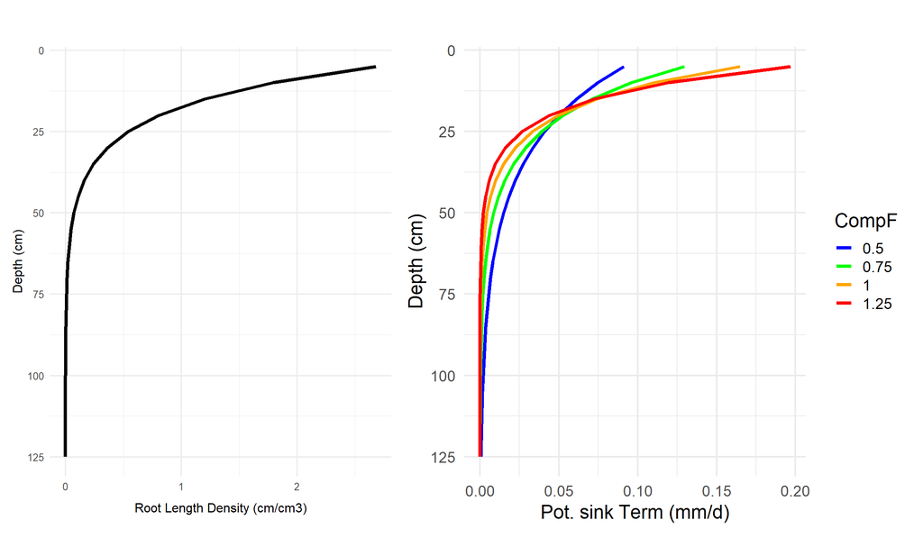

Figure 1: Example for an distribution of root length density within the soil profile and the distribution of the potential sink term calculated for different values of the competition factor (CompF).

## 2.4 Reduction of potential water uptake by soil water potential / soil water content

The potential sink term is reduced by the reduction factor for root water uptake (f<sub>sinkred</sub>). The reduction of potential water uptake by soil water potential / soil water content, f<sub>sinkred</sub>, is calculated by the soil water potential in each soil layer psi<sub>i</sub> [hPa], the soil water potential [hPa] psi<sub>0</sub> from which on water uptake is 0 and psi<sub>crit</sub> [hPa], a parameter for the soil water potential from which on water uptake decrease. For historical reasons this parameter psi<sub>crit</sub> is named psi2 in the code of the component TSoilWaterModelR.

With the option “psi_logscale” = false, the reduction factor for root water uptake (f<sub>sinkred</sub>) based on the untransformed soil water potential in each soil layer (psi<sub>i</sub>), the soil water potential from which on water uptake is 0 (psi0) and a parameter for the soil water potential from which on water uptake decrease (psi<sub>crit</sub>) as shown in Eq. Eq. 10.

$$f_{sinkred}=max \left( 0, min \left(1, \frac{psi-psi_3}{psi_2-psi_3}\right) \right) \tag{3}$$

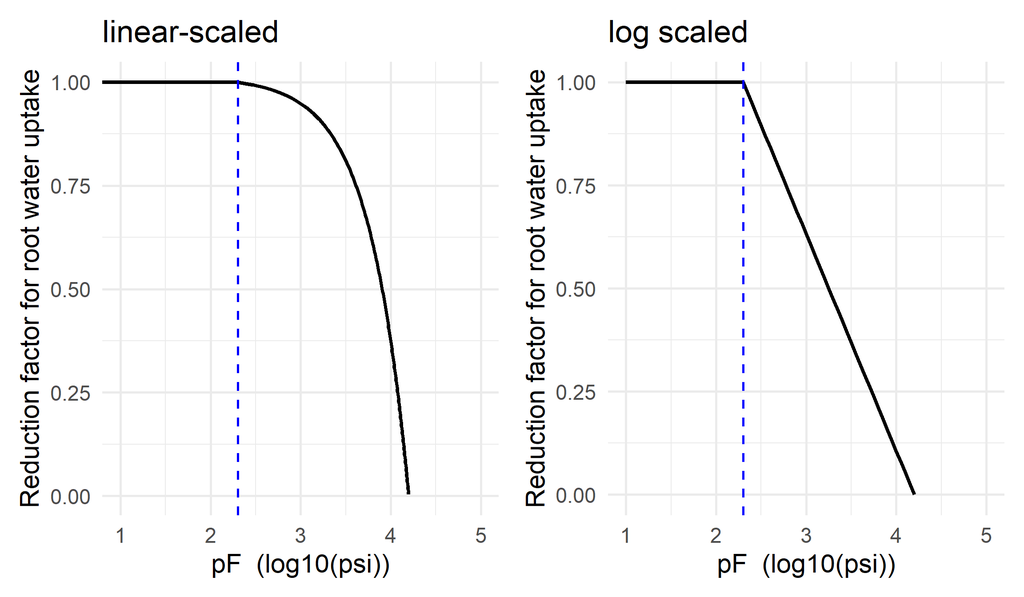

Figure 2: Examples of reduction function with either log scale or linear dependency on soil matrix potential. Dotted blue line indicates the value of psi_2, the soil water potential from which on water uptake decrease.

With the option “psi_logscale” = true the reduction factor is from log-scaled psi values:

$$f_{sinkred}=max \left( 0, min \left(1, \frac{log10(psi)-log10(psi_3)}{log10(psi_2)-log10(psi_3)}\right) \right) \tag{4}$$

The option “nFK<sub>crit</sub>” calculates the reduction factor for root water uptake (f<sub>sinkred</sub>) based on the soil water content in each soil layer (theta<sub>i</sub>), the soil water content from which on water uptake is 0 (theta0) and a parameter for the soil water content from which on water uptake decrease (theta<sub>crit</sub>) as shown in Eq. Eq. 5.

$$f_{sinkred}=max \left( 0, min \left(1, \frac{nFK-PWP}{nFK_{crit}-PWP}\right) \right) \tag{5}$$

For the option psicrit, the values of psi_2 is a fixed value during a simulation period. Its value is usually set to a value of around 200 hPa.

With the option *Feddes* it is variable, depending on the actual transpiration rate. The value of psi_2 is calculated based on the actual transpiration rate (T<sub>act</sub>) and the potential transpiration rate (T<sub>pot</sub>) as shown in Eq. Eq. 7.

$$\psi_{2,high} = max \left(\psi_2-\frac{\psi_{2,diff}}{2}, \psi_{FK} \right) \tag{6}$$

$$\psi_{2,low} = max\left(\psi_2+\frac{\psi_{2,diff}}{2}, \psi_{PWP}\right)$$

In between the value of $psi_2^{*}$ is calculated by linear interpolation (Eq. 7).

$$\psi_2^*=
\begin{cases}
\psi_{2,low} & \text{if } T_{act} \le T_{ref,low},\\
\psi_{2,high} & \text{if } T_{act} > T_{ref,high},\\
\psi_{2,low} + f \cdot (\psi_{2, high}-\psi_{2, low})
& \text{if } T_{ref,low} < T_{act} \le T_{ref,high}
\end{cases} \tag{7}$$

with:

$$f= \frac{T_{p} - T_{p,low}} {T_{ref,high} - T_{ref,low}} \tag{8}$$

```
[1] 1
```

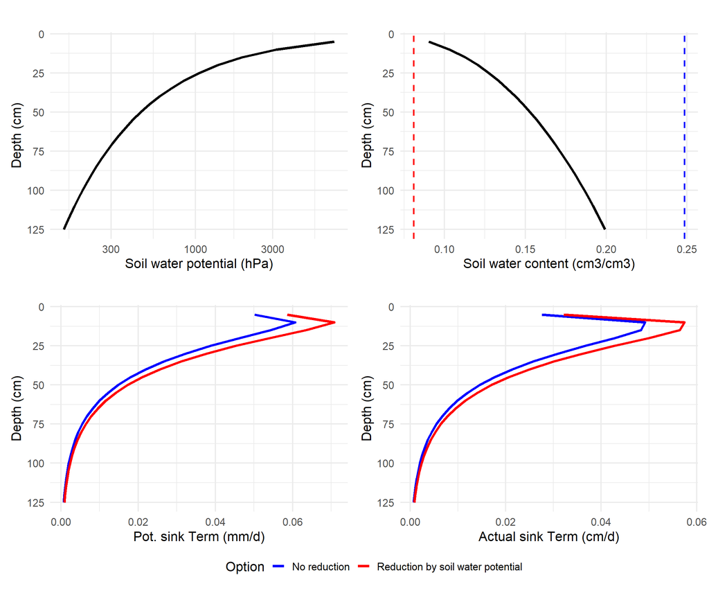

Figure 3: Example for the calculation potential sink term together with soil water potential and soil water content with depth with or without the inclusion of the reduction factor for distribution of potential sink term.

For the scenario shown in Figure 3, the actual transpiration rate (T<sub>act</sub>) is reduced by 24% if the reduction factor for root water uptake (f<sub>sinkred</sub>) is not considered in the distribution of the potential sink term. If the reduction factor for root water uptake (f<sub>sinkred</sub>) is considered in the distribution of the potential sink term, the actual transpiration rate (T<sub>act</sub>) is only reduced by 11% compared to the potential transpiration rate (T<sub>pot</sub>) (Table 2).

Table 2: Relative transpiration and reduction factor for root water uptake (f<sub>sinkred</sub>) for the two options to distribute the potential sink term.

| option | Tact | Tpot | Tact_Tpot |
| --- | --- | --- | --- |
| No reduction | 3.79 | 5 | 0.76 |
| Reduction by soil water potential | 4.42 | 5 | 0.88 |

TRUE

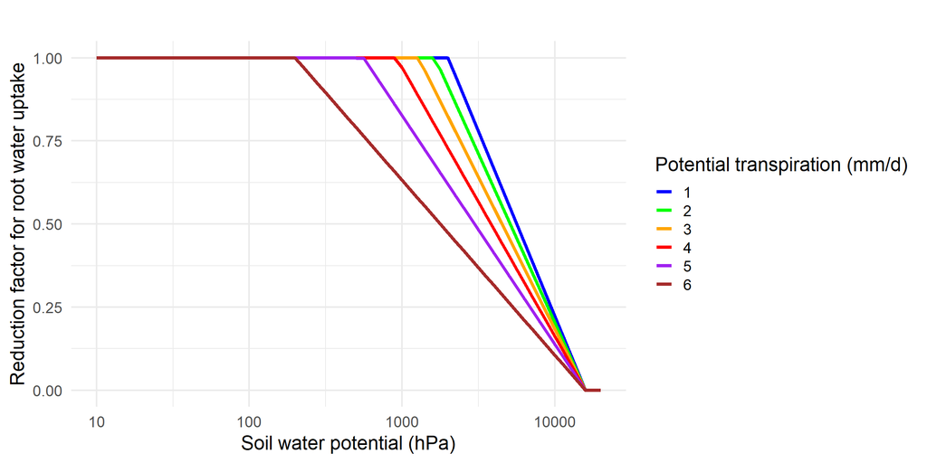

Within the component TSoilWaterModelR different options are available to calculate a *Feddes-like* reduction factor. The most simple approach is to neglect the effect of the actual transpiration rate on the reduction of root water uptake and to calculate the reduction factor for root water uptake (f<sub>sinkred</sub>) only based on the soil water potential in each soil layer (psi<sub>i</sub>), the soil water potential from which on water uptake is 0 (psi0) and a parameter for the soil water potential from which on water uptake decrease (psi<sub>crit</sub>) as shown in Eq. Eq. 9.

$$f_{sinkred}[i]=\left\{ \begin{align}
& 1\quad \quad \quad \quad \quad \quad |psi_i\le psi_2 \\
& \frac{ psi_i-psi_3}{psi_2-psi_3} \quad \quad |psi_i > psi_2 \\
\end{align} \right. \tag{9}$$

$${{f}_{\sin kred}}[i]=\left\{ \begin{align}
& 1\quad \quad \quad \quad \quad \quad \quad \quad \quad |ps{{i}_{i}}\ge ps{{i}_{crit}} \\
& \frac{\log (ps{{i}_{i}})-\log (ps{{i}_{0}})}{\log (ps{{i}_{crit}})-\log (ps{{i}_{0}})}\quad |ps{{i}_{i}}\ge ps{{i}_{crit}} \\
\end{align} \right. \tag{10}$$

The sum of the sink terms of the different soil layers is the actual transpiration [mm d<sup>-1</sup>] (T<sub>act</sub>).

$${{T}_{act}}=\sum\limits_{j}{S[j]} \tag{11}$$

The reduction factor for root water uptake (f<sub>sinkred</sub>) is calculated based on the soil water potential in each soil layer (psi<sub>i</sub>), the soil water potential from which on water uptake is 0 (psi0) and a parameter for the soil water potential from which on water uptake decrease (psi<sub>crit</sub>). There are different options available to calculate the reduction factor for root water uptake (f<sub>sinkred</sub>) as shown in Eq. 10, i.e. the version with logarithms of soil water tension as the independent variable.

## 2.5 More mechanistic approaches to calculate the reduction factor for root water uptake (f<sub>sinkred</sub>)

The above shown appproaches do not take into account the physical limitations of the rate of total water uptake which can be seen by the sum of the maximum transport rates to the segments of the whole root system.

### 2.5.1 Theoretical background

The theoretical background of the more mechanistic approaches is based on the calculation of water transport towards roots, for which the single root approximation (Figure 5) is the most used geometrical simplification, reducing the complex system of a real branched root system taking up water from a layered soil into the calculation of the one dimension transport in radial coordiates (Gardner (1960), Philip (1957), Carslaw and J.C. Jaeger (1946), van Lier et al. (2006), Metselaar and van Jong Lier (2011) and van Lier et al. (2013)).

The single root or ‘equivalent’ cylinder assumes the roots in one layer are organized in equally spaced parallel array. There are no analytical solutions of the diffusion equation sufficiently simple to be of general use for this case (see Youngs and Gardner (1963)), and numerical solutions or approximations have to be employed. The latter are most useful for discussing the general features of the system. Passioura and Cowan (1968) have discussed the two usual methods, the ‘steady state’ and ‘steady rate’ approximations.

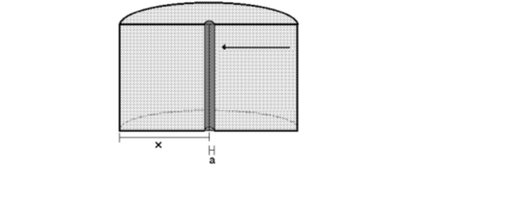

Figure 5: Single root cylinder

## 2.6 Calculation of water transport towards roots

The continuity equation for soil water ($\theta$) in radial coordinates is:

$$\frac{\partial \theta }{\partial t}=-\frac{\partial q }{\partial r} \tag{12}$$

where q is the flux density $[cm^3 \cdot cm^{-2} \cdot d^{-1}]$ of water towards the root surface and r is the distance from the root surface. The combination of the continuity equation with the Richards equation for radial coordinates yields:

$$\frac{\partial \theta }{\partial t}=\frac{1}{r}\frac{\partial }{\partial r}\left( {{r}\cdot}{{k}_{u}}(\theta )\cdot\frac{\partial \psi }{\partial r} \right) \tag{13}$$

Using the identity $\frac{d\theta }{d\theta }$ this can be written as:

$$\frac{\partial \theta }{\partial t}=\frac{1}{r}\frac{\partial }{\partial r}\left( r\cdot {{k}_{u}}\left( \theta \right)\cdot \frac{\partial \psi }{\partial \theta }\cdot \frac{\partial \theta }{\partial r} \right) \tag{14}$$

The specific soil water capacity is defined as:

$${{C}{(\psi }}{)}=\frac{d\theta }{d\psi } \tag{15}$$
Combined with the unsaturated soil hydraulic conductivity this with gives the definition of soil water diffusivity:

$${{D}_{w}}(\theta )={{k}_{u}}(\theta )\cdot \frac{1}{{{C}_{(\psi )}}} \tag{16}$$

which can be used to rewrite eq. Eq. 14 as:

$$\frac{\partial \theta }{\partial t}=\frac{1}{r}\cdot \frac{\partial }{\partial r}\left( r\cdot {{D}_{w}}\left( \theta \right)\cdot \frac{\partial \theta }{\partial r} \right) \tag{17}$$

For this partial differential equation analytic solutions exists, but only for special cases of the boundary conditions and for specific forms of the soil specific relationship for $D_w(\theta)$.

## 2.7 Analytical solutions of the radial water transport problem

Gardner (1960) and Philip (1957) first gave analytic solutions for boundary conditions given by (a) a constant rate (I<sub>w</sub>) of water uptake per unit root length $[cm^3cm^{-1}d^{-1}]$ where the inner boundary condition is given by:

$$I_w = -2\pi aK \frac{d\psi}{dr} \tag{18}$$
This can also be written in terms of soil water diffusivity and with a flux density $[d^{-1}]$ on the left hand side as the term $2\pi a$ is the root surface area per unit root length $[cm^2]$:

$$\frac{I_w}{2\pi a} = -D_w \frac{d\theta}{dr}=q \tag{19}$$

at r = a, and with the assumption of an infinite soil volume available for the sink, neglecting root competition, the solution is (Philip (1957), Carslaw and J.C. Jaeger (1946)):

$$\overline{\psi_s}-\psi_a=\frac{I_w}{4\pi K_u}\left[ln\left(\frac{4D_wt}{a^2}\right)-0.5772\right] \tag{20}$$

where $\overline{\psi_s}$ and $\psi_a$ are the water potentials at the root surface and in the bulk soil, and a is the root radius. The value 0.5772 is the so called Euler-Mascheroni constant.

A similar formulation based on diffusivity and for water content differences is given by van Lier et al. (2006):

$$\overline{\theta_s}-\theta_a=\frac{x^2T_p}{4z D_w}\left[ln\left(\frac{4D_wt}{a^2}\right)-0.5772\right] \tag{21}$$

The first terms on the right hand side of Eqs. Eq. 20 and Eq. 21 contain different formulations of the dimensionless change of water content per day, which are, however, equivalent and can be transformed into terms which have the units of $d^{-1}$.

$$\frac{{{I}_{w}}}{\pi }=\frac{{{x}^{2}}{{T}_{p}}}{z} \\
\\
\frac{{{I}_{w}}}{\pi {{x}^{2}}}=\frac{{{T}_{p}}}{z} \\$$

The solution of the equation Eq. 21 needs values for the soil water diffusivity and the unsaturated hydraulic conductivity as a function of volumetric soil water content or matrix potential, respectively.

## 2.8 Steady state and steady rate solutions for finite soil volumes

The above equation assumes that each root absorbs water from an infinite amount of soil, and that there is always more soil, at a steadily increasing distance, which can be drawn upon. In real root-soil systems this is not correct, since roots compete, and each root can be assumed to have a limited amount of soil for its sole exploitation. The root surface water potential will therefore fall faster than predicted above, and the mean water content and potential of the soil volume will decrease steadily.

### 2.8.1 Boundary conditions

For t > 0 and at the root surface, i.e. the inner boundary condition, the water influx rate per unis root length $I_w$ is derived from the daily crop transpiration rate $\overline{T_w}$ $[cm^.d^{-1}]$ and the total root length $L_r$ $[cm^.cm^{-2}]$. The most simple assumption is that the water uptake rate is equal for the whole root system:

$$t>0, \; r=a, \; 2\pi rD_w \left( \theta \right) \frac{\partial \theta }{\partial r} = \overline{I_w} \frac{\left( x^2-r^2 \right)}{\left( x^2-a^2 \right)} = \frac{\overline{Tr}}{2\pi a L_r} = -\frac{\overline{I_w}}{2\pi a} \tag{22}$$

A bit more realistic is the assumption of a diurnal variation of transpiration rate and water influx rate following the radiation intensity:

$$I_w\left( t \right)=\frac{Tr\left( t \right)}{L_r}=\frac{{{\overline{{{T}_{r}}}}\cdot}{{\frac{5}{3}}\cdot}\left[ 0.5+sin\left( {{\pi }^{.}}\frac{t}{12}+1.5 \right) \right]}{{{L}_{r}}} \tag{23}$$

It was further assumed that the water potential at the root surface can not be lower than the permanent wilting point, defined as a water potential of 1.5 MPa.

#### 2.8.1.1 outer boundary condition

It was assumed that there is a watershed between two neighboring roots. At this line the flow rate is zero:

$$t>0, \; r=x \;\;\;2\cdot{\pi }\cdot x \cdot D_w \cdot \frac{\partial\theta }{\partial r}=0 \tag{24}$$

### 2.8.2 Steady state solution:

For a steady state, it is assumed that all the water is injected into the system at the periphery of the equivalent cylinder, and the appropriate equation is for the steady state flow in a cylinder:

$$\psi_x-\psi_a=\frac{I_w}{2\pi K}ln\left( \frac{x}{a}\right) \tag{25}$$

or with water content differences and diffusivity:

$$\theta_x-\theta_a=\frac{I_w}{2\pi D_w}ln\left( \frac{x}{a}\right) \tag{26}$$

where x is the radius of the equivalent cylinder. Water is in fact being removed from the equivalent cylinder all the time, and this is allowed for by calculating the water loss after some convenient time interval at

$$\frac{\Delta \theta}{\Delta t}=\frac{I_w}{\pi (x^2-a^2)}\approx \\
\frac{I_w}{\pi x^2} \tag{27}$$

and recalculating with the new values of $\psi_b$ $K_u$ or $D_w$ to allow for the change in $\theta$.

The steady rate approximation (Cowan (1965)) is rather more realistic, since it embodies the assumption that water is being supplied uniformly from within the soil cylinder to maintain the constant flow (Figure 5). The equation for this system is

$${2\pi r{D}_{w}}\left(\theta \right)\frac{\partial \theta }{\partial r}=\overline I_w \frac{\left(x^2-r^2\right)}{\left(x^2-a^2\right)} \tag{28}$$

this yields:

$$\theta_b-\theta_a=\frac{I_w}{2\pi D_w}\left[ \frac{x^2}{x^2-a^2}ln\left(ln\frac{x}{a} \right)-\frac{1}{2}\right] \tag{29}$$

The solutions are therefore closely similar, but, for constant $\theta_b$, the steady rate equation predicts a value of $\theta_a$ (for constant $\theta_b$) which is identical to that of the steady-state equation at r = 1.65a. The equations are most useful in the relation to the mean water content $\overline\theta$, rather than $\theta_b$ and then give (Passioura and Cowan (1968)) a steady-state approximation for x >> a, which is valid for most cases:

$$\overline{\theta}=\theta_a+\frac{I_w}{2\pi D_w}\left(\frac{x^2}{x^2-a^2}ln\frac{x}{a}-ln\frac{1}{2} \right) \approx \theta_a+\frac{I_w}{2\pi D_w}ln\frac{x}{1.65a} \tag{30}$$

A similar equation can be defined by using unsaturated soil hydraulic conductivity and soil matriax potential:

$$\overline{\psi}=\psi_a+\frac{I_w}{2\pi k_u}\left(\frac{x^2}{x^2-a^2}ln\frac{x}{a}-ln\frac{1}{2} \right) \approx \psi_a+\frac{I_w}{2\pi k_u}ln\frac{x}{1.65a} \tag{31}$$

Rearranging for I<sub>w</sub> gives:

$$I_w=2\pi k_u \cdot \frac{\psi_a-\overline{\psi}}{ln\frac{x}{1.65a}} \tag{32}$$

### 2.8.3 Steady rate solution

The steady rate approximation (Cowan (1965)) is rather more realistic, since it embodies the assumption that water is being supplied uniformly from within the soil cylinder to maintain the constant flow. The steady-rate solution and its approximation for x >> a is (Tinker (1976)):

$$\overline{\theta}=\theta_a+\frac{I_w}{2\pi D_w\left( x^2-a^2\right)}\left[ \left(\frac{x^4}{x^2-a^2}ln\frac{x}{a}\right)-\left(\frac{3x^2-a^2}{4}\right) \right] \approx \theta_a+\frac{I_w}{2\pi D_w}ln\frac{x}{2.1a} \tag{33}$$

If one rearranges equation Eq. 33 for $I_w$ and assumes that $\theta_a$ is equal to $\theta_{PWP}$ (water content at the permanent wilting point) one gets the maximum possible water uptake rate under the given conditions $Iw_{max}$:

$$Iw_{max}=2\pi {{D}_{w}}\cdot \frac{{{\left( \overline{\theta }-{{\theta }_{PWP}} \right)}}}{ln\left( \frac{x}{2.1a} \right)} \tag{34}$$

## 2.9 Water content distribution around roots

The water content $\theta_r$ in any distance r from the root center then is given by:

$$\theta_{r}=\theta_a\left( 1+{\frac{I_w}{2\pi Dw}}ln\left( \frac{r}{a} \right) \right) \tag{35}$$

In Figure 6 the water content distribution around roots is shown for different values of the water uptake rate per unit root length (I<sub>w</sub>) and for different values of the soil water diffusivity (D<sub>w</sub>), as affected by texture and volumetric soil water content, which decreases during the simulated extraction of water from an isolated single root cylnder. The water content at the root surface is lower than in the bulk soil, and the difference increases with increasing water uptake rate per unit root length (I<sub>w</sub>) and decreasing soil water diffusivity (D<sub>w</sub>). The silty soil (Ut2) with the higher soil water diffusivity (D<sub>w</sub>) shows a smaller difference between the water content at the root surface and in the bulk soil than the sandy soils (Sl3 and especially gS) with the lower soil water diffusivity (D<sub>w</sub>).

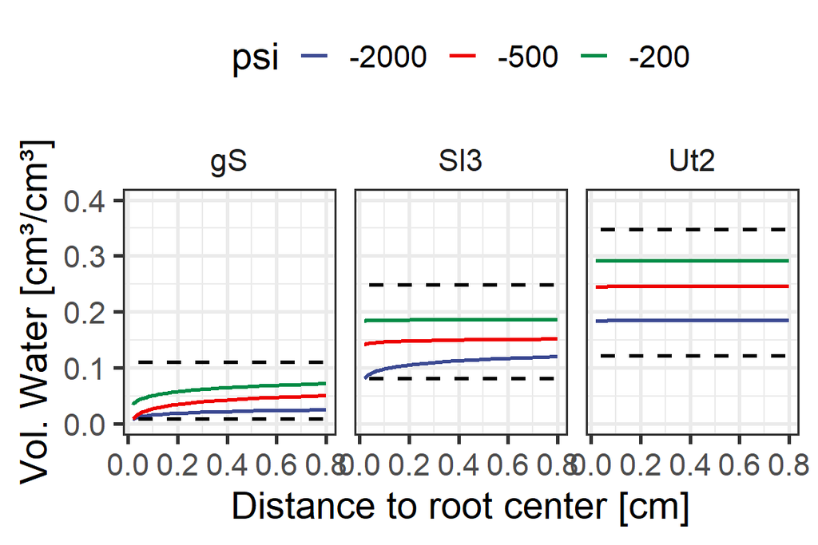

Figure 6: Water content distribution around roots at different soil water potentials and for three different soil textures calculated with the steady rate model. Upper dotted line: field apacity, lower dotted line: permanent wilting point

The accuracy of the above shown approaches is, however, limited, as the assumption of a constant soil water diffusivity with respect to the radial distance to the root surface is obviously not correct. As the soil water content decreases near the root surface, the soil water diffusivity decreases as well, leading to a self reinforcing effect.

### 2.9.1 Definition of matric flux potential

The matric flux potential (M) is a mathematical integration of unsaturated hydraulic conductivity over soil matric potential. It simplifies the non-linear governing equations of unsaturated soil water transport (such as Richards’ equation) by combining conductivity and tension into a single scalar potential variable.

van Lier et al. (2006) with correction by Schröder et al. (2007) derived an expression to describe M as a function of the radial distance from the root surface r [cm], based on the continuity equation for one‐dimensional axisymmetric flow Matric flux potential $(M) \left[ {cm^{2} d^{−1}} \right]$ is defined as the integral of unsaturated hydraulic conductivity, $K(h) [cm^.d^{−1}]$, over pressure head, or equivalently, as the integral of diffusivity, $D(θ) \left[cm^2d^{−1}\right]$, over volumetric water content $(\theta) \left[cm^{3}cm^{−3}\right]$. For convenience, the permanent wilting point in terms of pressure head $(h_w) \left[cm\right]$ or water content $\theta{_w} \left[cm^{3}cm^{−3}\right]$ is chosen as the lower bound of the integral:

$$M=\int_{-h_w}^{h}K(h)dh=\int_{\theta{_w}}^{\theta}D(\theta)d(\theta) \tag{36}$$

The Matric flux potential can be calculated numerically by integrating $k_u$ or $D_w$ from the permanent wilting point. Figure 7 gives the curves for the matrix flux potential for three chosen soil textures (gS: coarse sand, Sl3: loamy sand, Ut2: clayey silt).

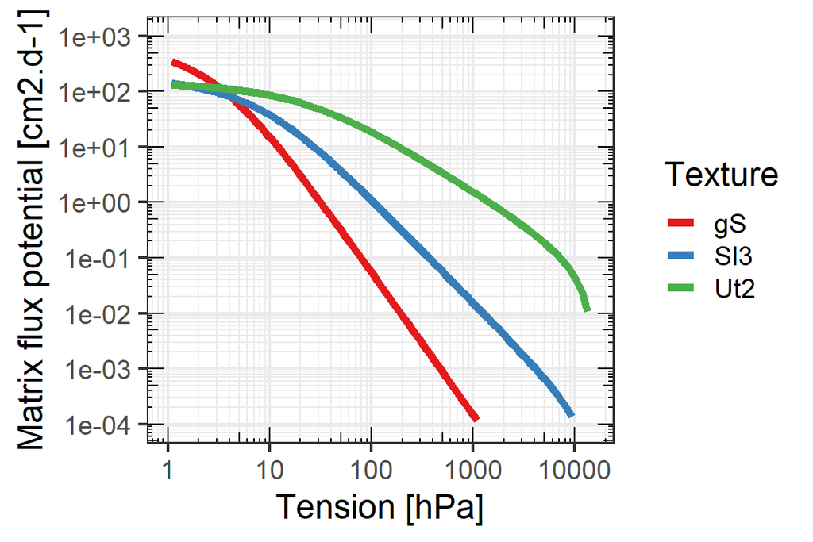

Figure 7: Matrix flux potential vs. soil water tension for three different soil texture types

## 2.10 Single root model with matrix flux potential

Solutions of Eq. 17 using the matric flux potential approach were derived by de_Willigen and Van_Noordwijk (1987) and were more recently used to derive sink term formulation of macroscopic soil water transport models by van Lier et al. (2006), Schröder et al. (2007) and de Jong van Lier, Q. de et al. (2008).

From mass conservation, and ignoring the root volume it follows that:

$$\frac{\partial\overline{\theta}}{\partial t}=-\frac{T_p}{z} \tag{37}$$

where $\overline{\theta}$ is the average water content in the entire rhizosphere and z [cm] is the rooting depth.Assuming that $\frac{d\theta}{dt}$ is independent of r Eq. can be generalized:

$$\frac{\partial\theta}{\partial t}=-\frac{T_p}{z} \tag{38}$$

According to van Lier et al. (2006) eq. 38 a second order differential equation follows:

$$-\frac{T_p}{z}=\frac{I_wL}{z}=-\frac{-q}{r}-\frac{\partial q}{\partial r}=\frac{\partial M}{r\partial r}+\frac{{{\partial }^{2}}M}{\partial {{r}^{2}}} \tag{39}$$

For this equation the following solution is found (van Lier et al. (2006) eq. 39):

$$M=\frac{-T_p}{4z}r^2+C_1ln(r)+C_2 \tag{40}$$

where $C_1$ and $C_2$ are integration constants. This solution is known as the steady-rate solution. We assume the continuum approach required to apply Darcy’s equation to hold for the geometry and the scales considered. van Lier et al. (2006) and Schröder et al. (2007) used the boundary condition

$$M=0;\;\;\;\;r=a \tag{41}$$

where a (cm) is the root radius, to express the conditions at the onset of the falling rate phase, i.e. when transport of water towards the roots is limiting water uptake rate.

To be representative for the entire constant rate phase, here we use:

$$M=M_0;\;\;\;\;\;\;r=a \tag{42}$$

where $M_0\;[cm^2d^{−1}]$ is the matric flux potential at the root surface. The second inner boundary condition remains:

$$\frac{dM}{dr}=T_p\frac{x^2}{2za};\;\;\;\;\;r=a \tag{43}$$
where x (cm) is the rhizosphere radius, which is equal to the half mean distance between roots and is related to the root length density $L_{rv}\;[cm\;cm^{−3}]$ by $x=(\pi L_{rv})^{-1/2}$.

Applying these boundary conditions (Eq. [11] and [12]) yields (Schröder et al. (2007), de Jong van Lier, Q. de et al. (2008)):

$$C_1=\frac{T_p}{2z}(x^2+a^2) \tag{44}$$

and de Jong van Lier, Q. de et al. (2008):

$$C_2=\frac{T_p}{2z}\left[\frac{a^2}{2}-(x^2+a^2)\:ln(a)\right]+M_0 \tag{45}$$
which combines to (de Jong van Lier, Q. de et al. (2008))

$$M-M_0=\frac{T_p}{2z}\left[\frac{a^2-r^2}{2}+\left(x^2-a^2\right)\:ln\left(\frac{r}{a}\right)\right] \tag{46}$$

Metselaar and de Jong van Lier, Quirijn (2007) showed by numerical analysis that M(r) under limiting hydraulic conditions has the same shape as under non-limiting conditions and may be described with an expression, with $T_p$ replaced by the actual transpiration rate $T_a$ and $M_0$ equal to the matric flux potential at the permanent wilting point ($M_w$), which by definition is equal to zero under limiting soil water conditions. Therefore, in the falling rate phase,

$$M=\frac{T_a}{2z}\left[\frac{a_z^2-r^2}{2}+\left(x_z^2+a_z^2\right)\:ln\left(\frac{r}{a}\right)\right] \tag{47}$$

replacing $T_p/z$ with $I_w/(\pi x^2)$ gives an equation for the distribution of matric flux potential around the roots based on influx per unit root length:

$$M=\frac{I_w}{2\pi x^2}\left[\frac{a_z^2-r^2}{2}+\left(x_z^2+a_z^2\right)\:ln\left(\frac{r}{a}\right)\right] \tag{48}$$

To calculate water uptake per layer, de Jong van Lier, Q. de et al. (2008) substituted the $T_p/z$ term by the root water uptake per unit of thickness for layer z, $S_z$ $(cm^3 cm^{−3} d^{−1})$:

$$M_z-M_{0,z}=\frac{S_z}{2}\left[\frac{a_z^2-r^2}{2}+\left(x_z^2-a_z^2\right)\:ln\left(\frac{r}{a_z}\right)\right] \tag{49}$$

in which the index z refers to layer‐dependent parameter.

At a radial distance from the root surface $\overline{r}$ (cm), the water content is equal to the mean (bulk) soil water content in the rhizosphere, and $\overline{M}$ $[m^2\:d^{−1}]$ is the corresponding matric flux potential. A coefficient $d_z$ can be defined as

$$d_z=\frac{\overline{r_z}}{x_z} \tag{50}$$

Using analytic methods, the value of d was shown to be $e^{−1/2}$ (≈0.607) assuming a constant diffusivity by van Lier et al. (2006) For soils with van Genuchten hydraulic functions, these authors showed with numerical simulations that the value of d is slightly lower (0.56 ± 0.06, with a median value of 0.53). Substituting $\overline{M}$ and $\overline{r}$ into Eq. [18] and incorporating Eq. [19] yields

$$\overline{M_z}-M_{0,z}=\frac{S_z}{2}\left[\frac{a_z^2-d_z^2x_z}{2}+\left(x_z^2+a_z^2\right)\:ln\left(\frac{d_zx_z}{a_z}\right)\right] \tag{51}$$

It should be noted that $\overline{M_z}$ is the matric flux potential calculated from the average soil water tension or the average volumetric soil water content of each layer, which can be straightforward calculated by (numerical) integration of $K_u(\psi)$ or $D_w(\theta)$ for each soil layer.

The above equation again could be formulated to use the water influx per unit root length and setting $M_{0,z}$ to zero for limiting soil water conditions. This then estimates the maximum water uptake per unit root length for the given soil conditions:

$$I_{wmax}=\frac{4\overline{M_z} \pi x^2}{a_z^2-d_z^2x_z+2\left(x_z^2+a_z^2\right)\:ln\left(\frac{d_zx_z}{a_z}\right)} \tag{52}$$
the value of $d_z$ estimated to be 0.56.

According to this approach also the matric flux potential an the root surface can be calculated from the specific soil water influx and the average matric flux potential within the root cylinder:

$$M_{0}=\overline{M_z}-\frac{I_w}{2\pi x^2}\left[\frac{a_z^2-(d_zx_z)^2}{2}+\left(x_z^2+a_z^2\right)\:ln\left(\frac{d_zx_z}{a_z}\right)\right] \tag{53}$$
Thereby the water influx is the minimum of the transpirational demand divided by the total root length or the maximum transport limited influx rate $I_{wmax}$.

The profile of the matric flux potential then is given by:

$$M\left( r \right) = M_0 + \frac{I_w}{(2 \cdot pi \cdot x^2)}\cdot\frac{a^2-r^2}{2}+(x^2+a^2)\cdot ln\left(\frac {r}{a}\right) \tag{54}$$

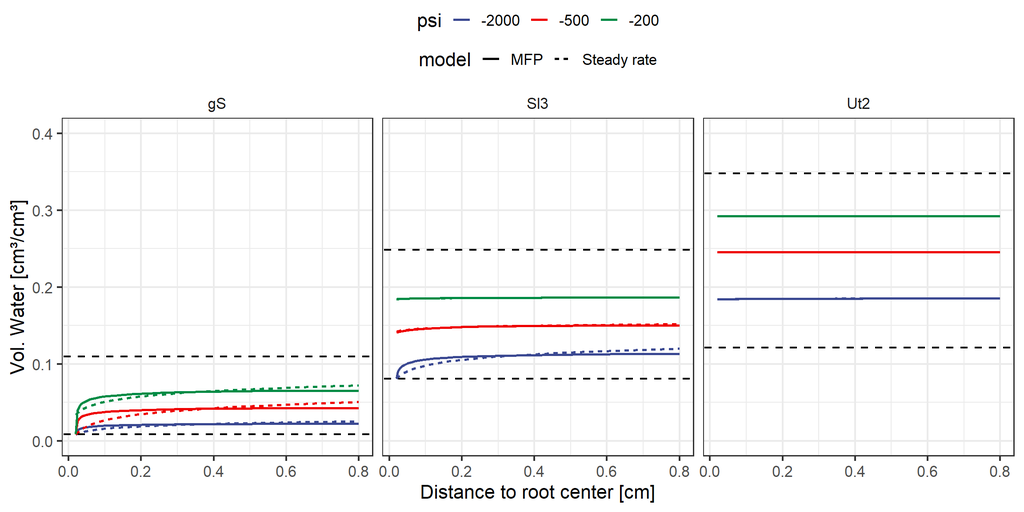

TRUE

```r
#|label: fig-WcontProfilesMFP
#|echo: FALSE
#|message: FALSE
#|warning: FALSE
#|fig.align: 'center'
#|fig.cap: "Water content distribution around roots at different soil water potentials and for three different soil textures calculated with the matrix flux potential model. Upper dotted line: field apacity, lower dotted line: permanent wilting point"

p <- ggplot(data = df.swcr.all)
p <- p + theme_bw(base_size = 16)
p <- p + geom_line(aes(x=r, y=theta_r, color=psi, lty=model), size=1)
p <- p + geom_abline(data = df.MFP, aes(slope = 0, intercept = PWP), lty=2)
p <- p + geom_abline(data=df.MFP, aes(slope = 0, intercept = FK), lty=2)
p <- p + facet_wrap(facets = vars(Texture))
p <- p + scale_y_continuous(limits = c(0, 0.4))
#p <- p + scale_y_log10()
p <- p + theme(legend.position = "top",legend.box="vertical", legend.margin=margin())
p <- p + xlab("Distance to root center [cm]") + ylab("Vol. Water [cm³/cm³]")
p <- p + scale_color_aaas()
p <- p + theme(strip.background = element_blank())
p
```

From which the water uptake rate per soil layer then is:

$$S_{z}=\frac{4\left(\overline{M_z}-M_{0,z}\right)}{a_z^2-0.56^2x_z^2+2(x_z^2-a_z^2)\;ln\frac{0.56\:x_z}{a_z}} \tag{55}$$

Because $\overline{M_{0,z}}$ is zero for limiting soil water conditions, i.e. the falling phase of root water uptake in a layer at the maximum water uptake rate per soil layer is:

$$S_{z,max}=\frac{4\overline{M_z}}{a_z^2-0.56^2x_z^2+2(x_z^2-a_z^2)\;ln\frac{0.56\;x_z}{a_z}} \tag{56}$$

### 2.10.1 Comparison of the steady rate and matric flux potential approach

In Figure 8 the water content distribution around a single root cylinder is shown for the steady rate and matric flux potential approach during a simulated water extraction period as an animated gif. As during the simulated water extraction period the soil water content decreases, the difference between the water content at the root surface and in the bulk soil increases. The difference is larger for the steady rate approach than for the matric flux potential approach, which is more realistic as it accounts for the decrease of soil water diffusivity with decreasing soil water content.

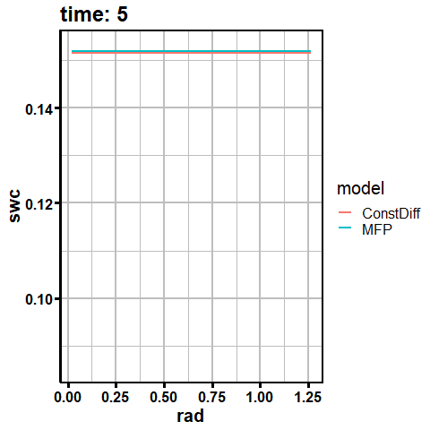

Figure 8: Simulation of water uptake from a single root cylinder

### 2.10.2 Implementation of the matric flux potential approach in the TSoilWaterModelR

The root length density used by the `MFP` sink method is the hydraulically active fraction of the available root length density:

$$L_{rv,act}=f_{act}L_{rv} \tag{57}$$

Here, $f_{act}$ is the parameter `FracActRoots` [-], with a default value of 0.3. The active root length density determines both the mean distance between active roots and the maximum uptake rate. With classes enabled, the factor is applied separately to every root length density class. Other water sink methods are unaffected, and the factor is not yet applied to nitrate uptake.

Potential transpiration is first allocated to the selected hydraulic units (soil layers or root length density classes). Actual uptake is then limited independently in every unit:

$$S_{act,k}=min\left(S_{pot,k},S_{max,k}\right) \tag{58}$$

The two MFP options give four symmetric combinations:

| `WithClasses` | `MFPuptakedistribution` | Potential-uptake allocation | Hydraulic limitation |
| --- | --- | --- | --- |
| `false` | `empirical` | Empirical root-length and competition-factor weights between layers | Layer-average MFP capacity |
| `false` | `MaximumFlow` | Relative maximum MFP capacity of each layer | Layer-average MFP capacity |
| `true` | `empirical` | Empirical root-length and competition-factor weights between all classes | Class-specific MFP capacity |
| `true` | `MaximumFlow` | Relative maximum MFP capacity of each class | Class-specific MFP capacity |

## 2.11 Approach for non-uniformly distributed roots

The log normal distribution has density

$$f(x) = \frac{1}{\sqrt{2\pi}\sigma x} e^{-(\log(x) - \mu)^2/2 \sigma^2} \tag{59}$$

where $\mu$ and $\sigma$ are the mean and standard deviation of the logarithm. The mean is $E(X) = exp(\mu + 1/2 \sigma^2)$ , the median is $med(X) = exp(\mu)$, and the variance $Var(X) = exp(2\mu + \sigma^2)(exp(\sigma^2) - 1)$ and hence the coefficient of variation is $\sqrt{exp(\sigma^2) - 1}$ which is approximately $\sigma$ when that is small (e.g., $\sigma < 1/2$).

## 2.12 Coupling root-density distributions to soil water

Assigning `PlantModel` to a `TGrowthCurvePlantRoots` component now connects both its mean layer densities and its live `Wld_moments` / `EffWld_moments` matrices. `TAbstractPlant` supplies optional virtual matrix getters; plants without these distributions return `nil`. `TSoilWaterModelR.SetPlantModel` refreshes the links on initialization and crop changes and clears obsolete links on disconnection. Separate root modules such as `TSimpleRootModDM` can still connect explicitly through `RootedSoilWaterModel` / `SetRootLengthDensityMomentMatrices`.

For variation to affect water contents, use `CalcMoments = true` in the root model, nonzero resulting `VK_lrv` coefficients, and `SinkTermMethod = MFP` with `WithClasses = true` in the soil-water model. The class uptake calculation reads **effective** root-density quantiles. A missing matrix falls back to the mean layer density; a linked zero row represents no active roots and gives zero uptake. Disabling `CalcMoments` gives uniform quantiles in both root models.

Each class starts with one tenth of the layer water amount. Different class uptake rates subsequently produce different water contents; vertical flow is shared equally among classes. `theta_stdev_XX` reports the resulting within-layer standard deviation in cm³/cm³. `SoilWaterAmountMatrix[i,j]` is the class’s contribution to layer water amount in cm, so its local volumetric water content is `10 * SoilWaterAmountMatrix[i,j] / Thick[i]`. The ten contributions sum to the layer’s `WAmount[i]`.

## References

Carslaw, H.W., J.C. Jaeger, 1946. Conduction of heat in solids. Clarendon Press, Oxford.

Cowan, I.R., 1965. Transport of water in the soil-plant atmosphere system. J. appl. Ecol. 2, 221–239.

de Jong van Lier, Q. de, van Dam, J.C., Metselaar, K., Jong, R.D., Duijnisveld, W.H.M., 2008. Macroscopic root water uptake distribution using a matric flux potential approach. Vadose Zone Journal 7, 1065–1078. https://doi.org/10.2136/vzj2007.0083

de_Willigen, P., Van_Noordwijk, M., 1987. Roots, plant production and nutrient use efficiency (Ph.D. thesis). Agricultural University Wageningen, The Netherlands.

Ehlers, W., Hamblin, A.P., Tennant, D., R. R. Van Der Ploeg, 1991. Root system parameters determining water uptake of field crops. Irrig.Sci. 12, 115124.

Feddes, R.A., Kowalik, P.J., Zaradny, H., 1978. Simulation of field water use and crop yield. Centre for Agricultural Publishing; Documentation, Wageningen.

Gardner, W.R., 1960. Dynamic aspects of water availability to plants. Soil Sci. 89, 63–73.

Holbrook, N.M., 2002. Stomatal control in tomato with ABA-deficient roots: Response of grafted plants to soil drying. Journal of Experimental Botany 53, 1503–1514. https://doi.org/10.1093/jexbot/53.373.1503

Jarvis, N.J., 1989. A simple empirical model of root water uptake. Journal of Hydrology 107, 57–72. https://doi.org/10.1016/0022-1694(89)90050-4

Metselaar, K., de Jong van Lier, Quirijn, 2007. The shape of the transpiration reduction function under plant water stress. Vadose Zone J 6, 124–139. https://doi.org/10.2136/vzj2006.0086

Metselaar, K., van Jong Lier, Q. de, 2011. Scales in single root water uptake models: A review, analysis and synthesis. European Journal of Soil Science 62, 657–665. https://doi.org/10.1111/j.1365-2389.2011.01385.x

Passioura, J.B., Cowan, I.R., 1968. ON SOLVING NON-LINEAR DIFFUSION EQUATION FOR RADIAL FLOW OF WATER TO ROOTS. Agricultural Meteorology 5, 129+. https://doi.org/10.1016/0002-1571(68)90044-7

Philip, J.R., 1957. The physical principles of soil water movement during the irrigation cycle, in: ICID (Ed.), Proc. Int. Congr. Comm. Irrig. Drain., Proc. Int. Congr. Comm. Irrig. ICID, New Dehli, pp. 125–154.

Schröder, T., Javaux, M., Vanderborght, J., Vereecken, H., 2007. Comment on “root water extraction and limiting soil hydraulic conditions estimated by numerical simulation.” Vadose Zone Journal 6, 524–526. https://doi.org/10.2136/vzj2007.0036

Tinker, P.B., 1976. Roots and water. Phil. Trans R. Soc. Lond. B 273, 445–461.

van Lier, Q. de J., Metselaar, K., van Dam, J.C., 2006. Root water extraction and limiting soil hydraulic conditions estimated by numerical simulation. Vadose Zone Journal 5, 1264–1277. https://doi.org/10.2136/vzj2006.0056

van Lier, Q. de J., van Dam, J.C., Durigon, A., dos Santos, M.A., Metselaar, K., 2013. Modeling water potentials and flows in the soil-plant system comparing hydraulic resistances and transpiration reduction functions. Vadose Zone Journal 12. https://doi.org/10.2136/vzj2013.02.0039

Youngs, E.G., Gardner, W.R., 1963. A problem of diffusion in the infinite hollow cylinder. Soil Science Society of America Journal 27, 475–476. https://doi.org/10.2136/sssaj1963.03615995002700040033x